# CCL Preview

Janette Avelar

2026-04-22

# What goals do CCL schools have?

Guiding question: **Which of these goals best describe your reason for innovating? Select up to 3.**

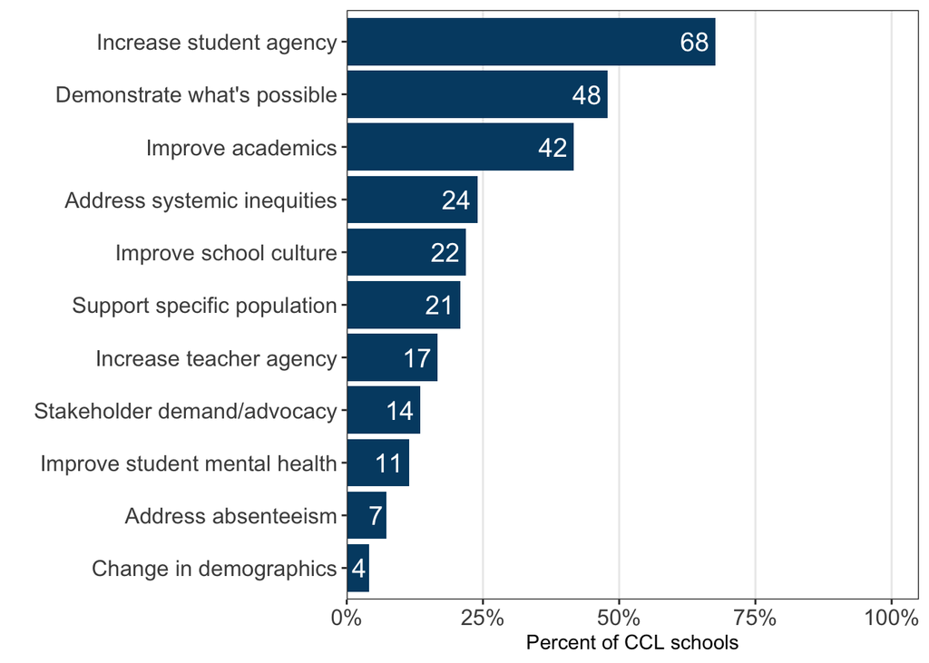

These goals are very similar to those that the wider Canopy sample selected.

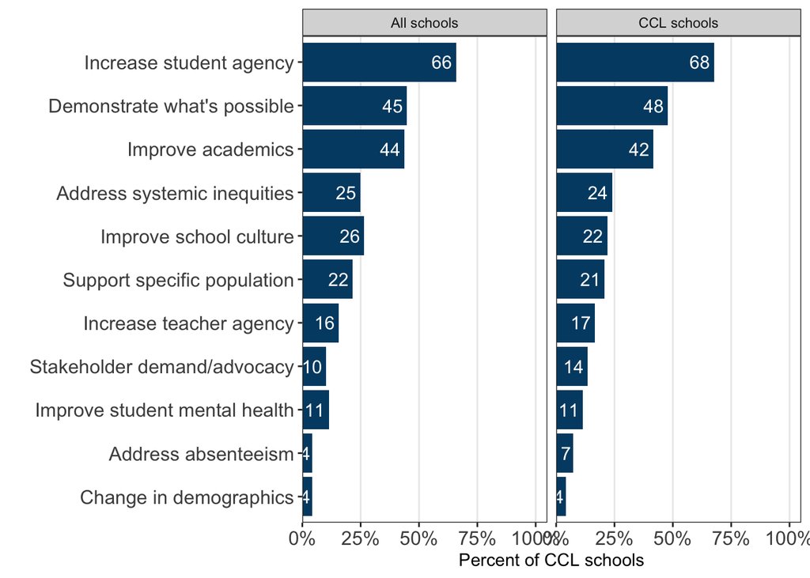

# How is CCL designed to meet those goals?

Guiding question: **In what ways is career-connected learning built into your overall school design?**

Designs follow an expected path - most schools are embedding CCL in their strategic plan/mission, across grade levels, in required coursework/pathways, and with core academics. They’re also engaging in individualized advising, schoolwide scheduling structures, and have dedicated staff.

Far fewer are integrating CCL with SEL structures, providing PD for staff, or assessing workplace competencies/technical skills.

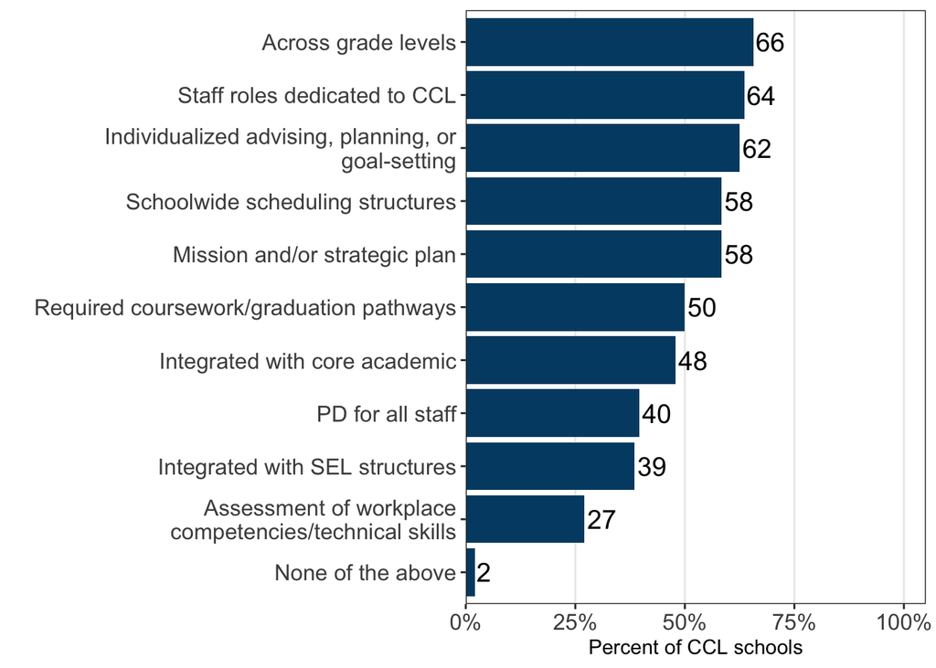

Might be interesting to see if this varies by grade level. (*Note:* How we construct grade level is not mutually exclusive so the total is greater than the number of schools.)

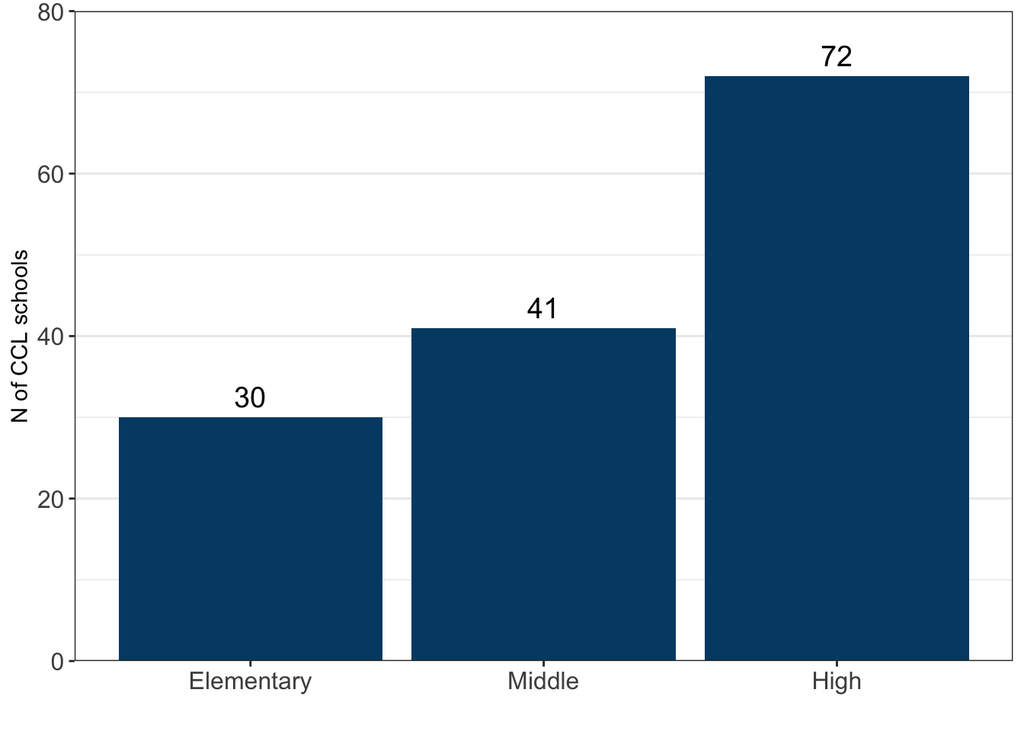

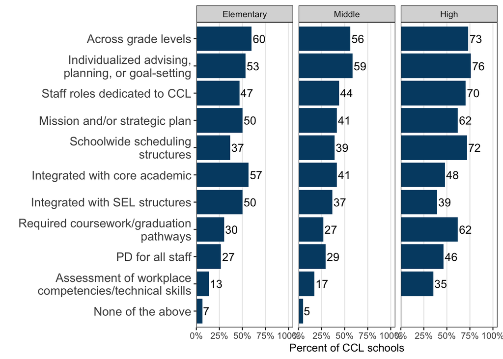

# What outcomes are CCL schools prioritizing and measuring? [i.e., how do they know if they’re successful?]

Guiding question: **How important are the following student outcomes in your school’s CCL approach?**

It’s a little difficult to get labels into this plot given most schools did not select any of the listed outcomes as not important. However, there are a few pieces here that really stand out:  
- 8 of the 96 CCL schools indicated that industry credentials are “Not important” while another 20 indicated they are “Somewhat not important”  
- 13 of the 96 CCL schools indicated that social capital is “Not important” (1) or “Somewhat not important” (12)  
- Nearly all (93% or 89) indicated that engagement is “Very important” - standing out as a clear priority for CCL schools  
- Belonging (90%) and durable skills (89%) were also at the top of the “Very important” list  
- No schools indicated that engagement, agency and self-direction, identity and purpose, or durable skills are “Not important” or “Somewhat not important”

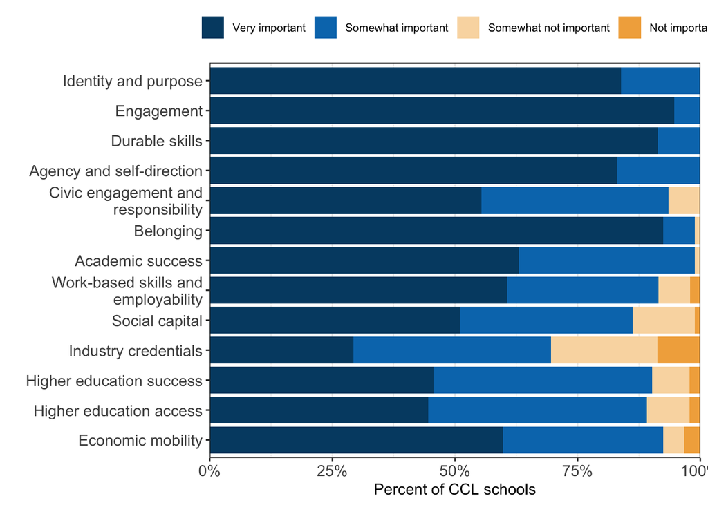

Here’s a more simplified version of the same plot:

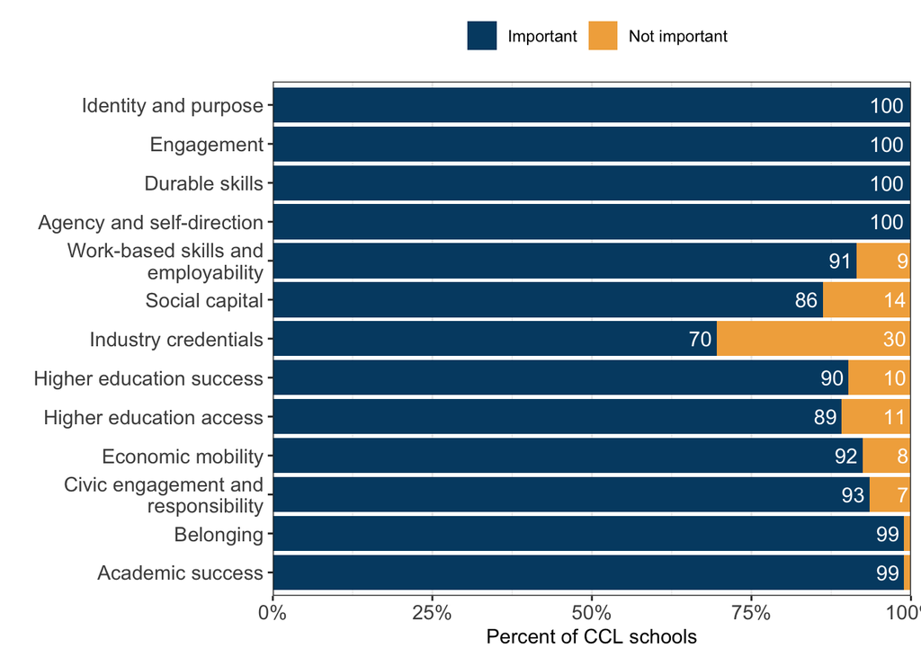

Next, probing to see if the differences go away when we break out by high school vs. not high school. Some small differences arise, including a 75/25 split on whether industry credentials are important among high schools (interesting) that’s more of a 50/50 split for schools that don’t serve high school grades.

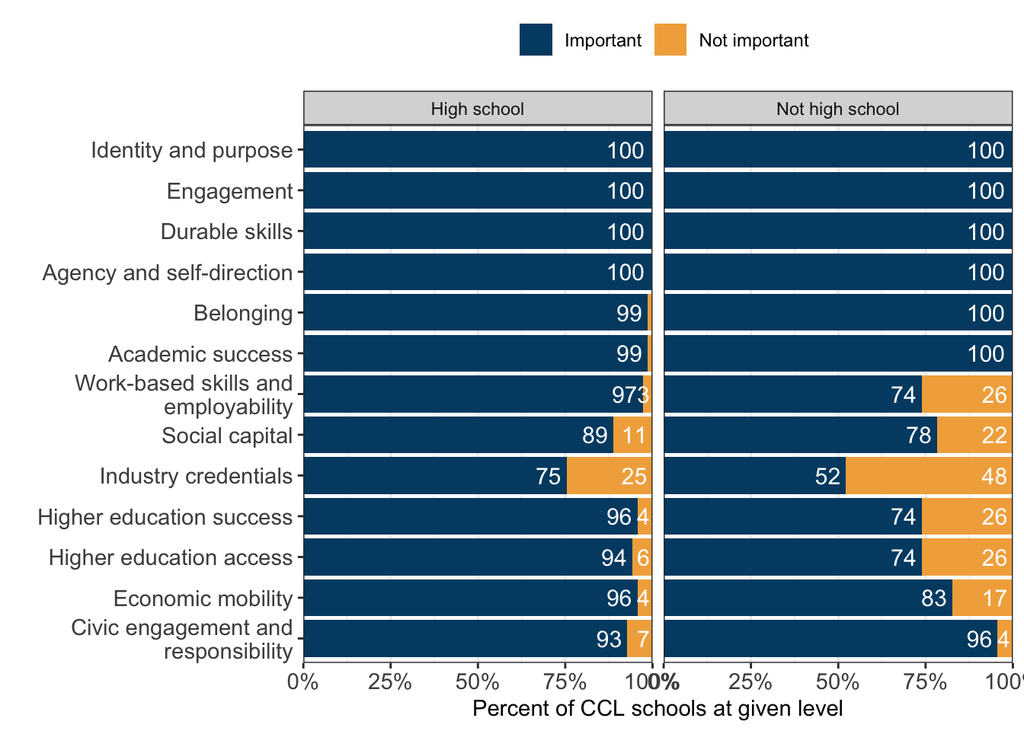

Among CCL schools that indicated some outcome is important, how many are actually measuring progress toward that goal?

Guiding question: **For the outcome(s) you indicated are important above, how does your school currently measure progress?**

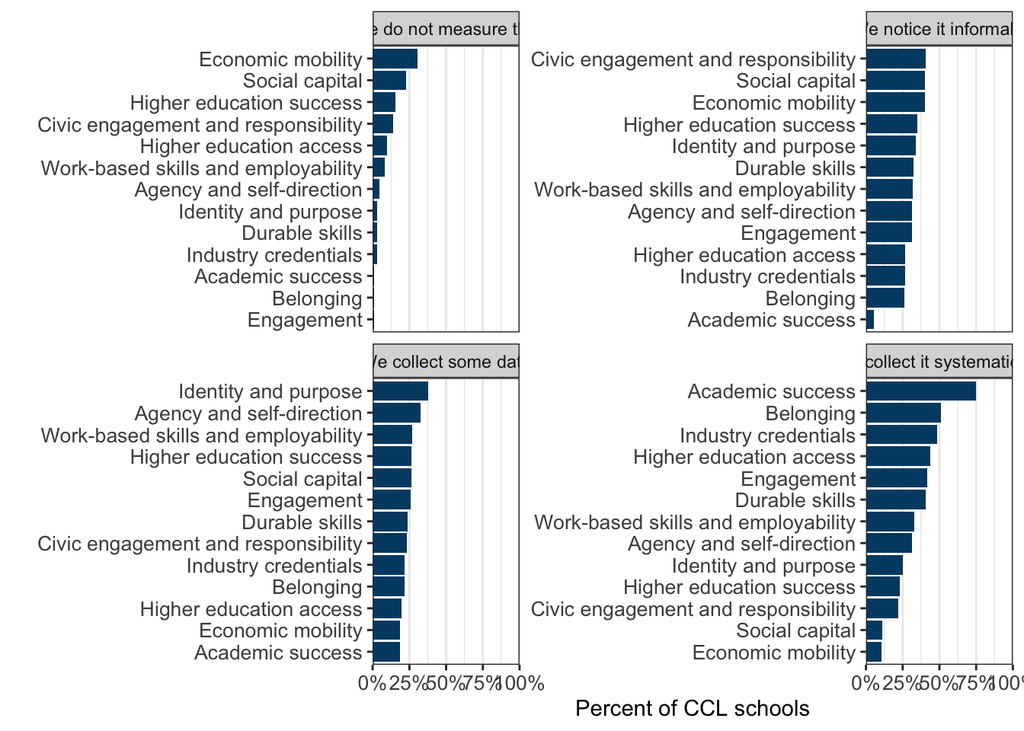

To make it easier to compare, here’s a version comparing systematic/some/none.

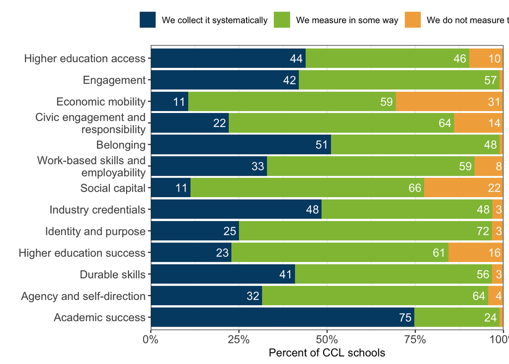

# What gets in the way of measuring progress toward their goals? [i.e., barriers and enablers]

Guiding question: **What are the biggest barriers your school faces when measuring progress toward the outcomes you care about?**

Two clear barriers stand out: over half of CCL schools cited that collecting data (51%) and having the capacity to regularly use that data (52%) are the biggest barriers their school faces when measuring progress. A quarter (26%) also reported they’re unsure what assessments or measures to use.

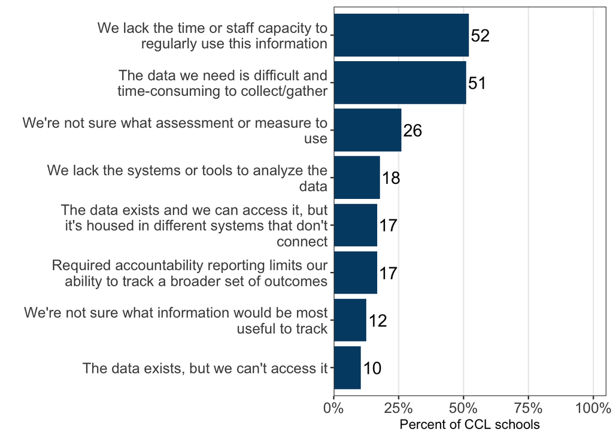